# Project 1

This is an R Markdown document that will explain how the data was analyzed to answer key questions required for this assignment.

### Prep work

Install libraries

```r
library("ggplot2", lib.loc="~/R/win-library/3.1")
```

read csv file into myData

```r
myData <- read.csv(file="activity.csv",sep=",",header=TRUE)
```

### Answer first question - “What is the mean total number of steps taken per day”

Sum number of steps for each date using aggregate function, do not include NA values

```r
sumbyday <- aggregate (steps ~ date, data=myData,sum,na.rm=TRUE)
```

Plot histogram using ggplot

```
## stat_bin: binwidth defaulted to range/30. Use 'binwidth = x' to adjust this.
```

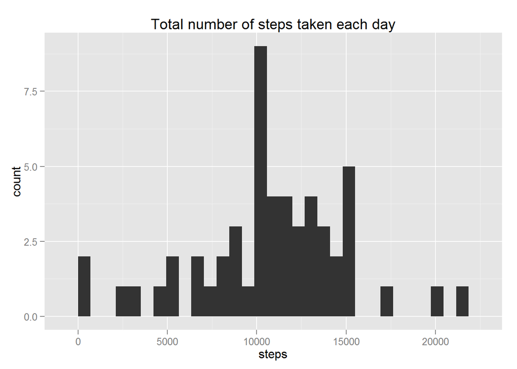

```r
d <- ggplot(sumbyday, aes(x=steps))
d + geom_histogram() + labs(title="Total number of steps taken each day")
```

Calculate the mean and median steps for the daily total

```r
smean <- mean(sumbyday$steps)
smedian <- median(sumbyday$steps)
```

The mean steps for the daily total is 1.076618910^{4}.

The median steps for the daily total is 10765.

### Answer the second question - “What is the average daily acitivy pattern?”

Calculate the average number of steps per 5-minute interval across all days using aggregate function

```r
meanbyinterval <- aggregate (steps ~ interval, data=myData,mean,na.rm=TRUE)
```

Plot mean # of steps by 5-minute interval using qplot

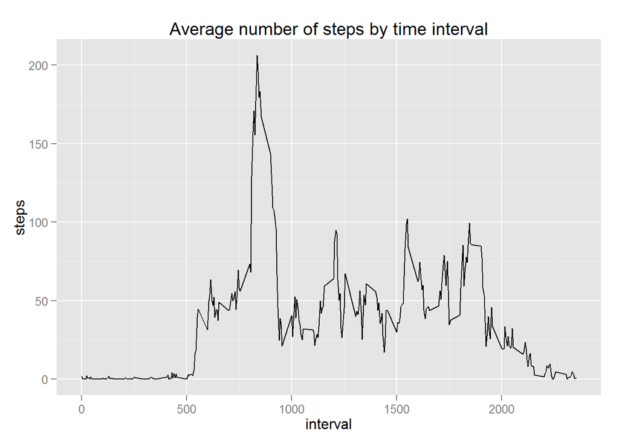

```r
qplot(y=steps, x=interval, data=meanbyinterval,geom ="line", main = "Average number of steps by time interval")
```

Deterime which 5-minute interval, on average across all days, contains the maxinum number of steps using which.max function

```r
inum <- meanbyinterval[which.max(meanbyinterval$steps),1]
```

Interval with maxinum number of steps is 835.

### Imputing missing values

Calculate the total number of msising values using sum of is.na

```r
numNA <- sum(is.na(myData$steps))
```

Number of NA values in data is 2304

Use the mean per interval to fill in the missing NA values, assign to stepsnoNA

```r
myData$stepsnoNA <- myData$steps
myData$stepsnoNA [is.na(myData$steps)] <-meanbyinterval$steps
```

Plot the histogram of the updated data with NA filled in by the mean step value at that interval

First calculate total number of steps per day with updated data…

```r
sumbydaynoNA <- aggregate (stepsnoNA ~ date, data=myData,sum,na.rm=TRUE)
```

…then plot histogram using ggplot

```
## stat_bin: binwidth defaulted to range/30. Use 'binwidth = x' to adjust this.
```

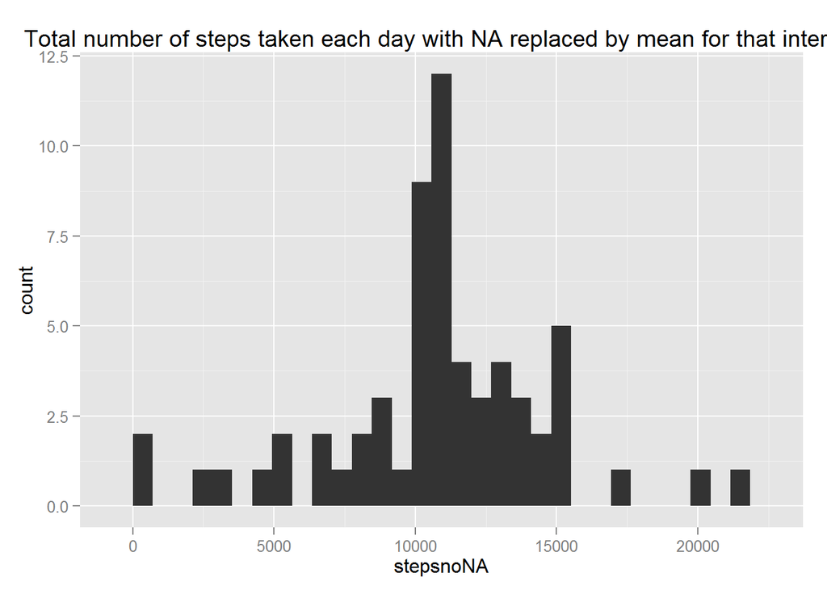

```r
dna <- ggplot(sumbydaynoNA, aes(x=stepsnoNA))
dna + geom_histogram() + labs(title="Total number of steps taken each day with NA replaced by mean for that interval")
```

Calculate the mean and median steps for the daily total

```r
s2mean <- mean(sumbydaynoNA$stepsnoNA)
s2median <- median(sumbydaynoNA$stepsnoNA)
```

The mean steps for the daily total is 1.076618910^{4}.

The median steps for the daily total is 1.076618910^{4}.

Compare summary statisics of both data sets Summary statistics with NA values removed

```r
summary(sumbyday$steps)
```

```
##    Min. 1st Qu.  Median    Mean 3rd Qu.    Max.
##      41    8841   10760   10770   13290   21190
```

Summary statistics with NA values changed to mean of steps for that interval

```r
summary(sumbydaynoNA$stepsnoNA)
```

```
##    Min. 1st Qu.  Median    Mean 3rd Qu.    Max.
##      41    9819   10770   10770   12810   21190
```

Impact of imputing mean by interval for NA values is slightly changing the distribution of the histrogram changine 1st, 2nd (median), and 3rd quartiles, but not he average, max or min

### Are there differences in activity patterns between weekdays and weekends?

Create new factor variable for weekday, and fill in values using weekdays function

```r
myData$weekday <- NA
myData$weekday <- weekdays(as.Date(myData$date))
```

Create new factor variable for weektype; subset data to weekend when weekday is Saturday or Sunday

```r
myData$weektype <- "Weekday"
myData$weektype [myData$weekday =="Saturday"] <- "Weekend"
myData$weektype [myData$weekday =="Sunday"] <- "Weekend"
```

Subset data for weekdays and weekends only

```r
weekendonly <- subset(myData, weektype =="Weekend")
weekdayonly <- subset(myData, weektype =="Weekday")
```

Get average steps for interval for weekdays and weekends only using imputed steps data

```r
meanbyweekend <- aggregate (stepsnoNA ~ interval, data=weekendonly,mean,na.rm=TRUE)
meanbyweekday <- aggregate (stepsnoNA ~ interval, data=weekdayonly,mean,na.rm=TRUE)
```

Plot the time series of 5-minute intervals of weekends versus weekdays

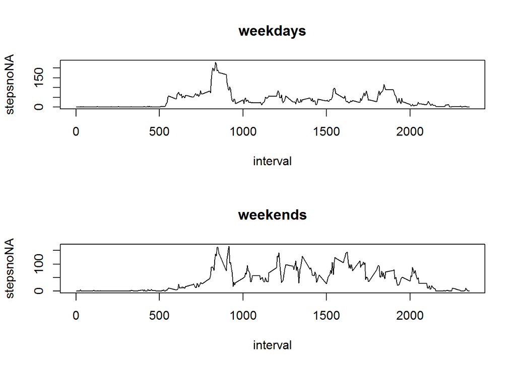

```r
par(mfrow = c(2, 1))
with (meanbyweekday, plot (interval, stepsnoNA, type="l",main="weekdays"))
with (meanbyweekend, plot (interval, stepsnoNA, type="l",main="weekends"))
```